# Analysis of NASDAQ Companies

**Author: Edris Kakar**

## Introduction

The Nasdaq 100 Index, a barometer of modern entrepreneurship and technological innovation, holds a pivotal role in the global financial landscape, emblematic of the prowess and potential of major technology and non-financial companies traded on the Nasdaq stock exchange. Comprising the 100 largest non-financial companies based on market capitalization, the index is not merely a list but a showcase of leading enterprises in sectors like technology, telecommunications, retail, and biotechnology. Its significance stems not only from its composition—giants like Apple, Amazon, Google’s parent Alphabet, and Microsoft—but also from its reflection of broader economic trends and its influence on global investment patterns. First and foremost, the Nasdaq 100 acts as a crucial gauge of the health and trajectory of the technology sector, which is increasingly synonymous with the overall economic direction in an ever-more digital world. As technology firms have grown in size and influence, they have become key drivers of economic growth, innovation, and productivity improvements. The performance of the Nasdaq 100 often provides investors and analysts with insights into the technological advancements and consumer trends shaping the market dynamics. For example, a surge in the index might indicate robust consumer adoption of technology, bullish investor sentiment on tech stocks, or a broader economic upswing fueled by technological innovation. Moreover, the global influence of the Nasdaq 100 extends beyond its constituent companies. It is a popular benchmark for fund managers and is heavily used in the creation of various investment products including index funds and exchange-traded funds (ETFs). This makes it a vital tool for both institutional and individual investors looking to tap into the growth potential of the largest non-financial companies in the U.S. The widespread use of the Nasdaq 100 as a benchmark ensures that movements in the index can have wide-ranging implications on global investment portfolios, influencing millions of investors and the allocation of trillions of dollars globally. Additionally, the Nasdaq 100 is renowned for its volatility and growth potential. Historically, it has outperformed broader indices, especially during times of strong technological growth and innovation. This has positioned it as a favored choice for growth-oriented investors seeking higher returns, albeit with higher risk. The high concentration of technology stocks means the index is particularly sensitive to changes in interest rates, government policy, and global economic conditions, making it an important indicator for market sentiment and economic health.

### Other Resources:

- [NASDAQ-100 Definition](https://www.investopedia.com/terms/n/nasdaq100.asp)
- [Nasdaq-100 Equal Weighted Index](https://www.investopedia.com/terms/ndxe.asp)
- [NASDAQ-100 Premarket Indicator](https://www.investopedia.com/terms/n/nasdaq100-premarket-indicator.asp)

### Other Resources:

- [Basics of Algorithmic Trading: Concepts and Examples](https://www.investopedia.com/articles/active-trading/101014/basics-algorithmic-trading-concepts-and-examples.asp)
- [Algorithmic Trading: Definition, How It Works, Pros & Cons](https://www.investopedia.com/terms/a/algorithmictrading.asp)

## Data Collection

The provided Python code snippet demonstrates how to scrape and analyze data from the Wikipedia page listing the components of the Nasdaq-100. Using libraries such as `pandas`, `requests`, and `BeautifulSoup`, the script fetches the webpage content, locates the specific table containing the Nasdaq-100 companies, and converts this table into a `pandas` DataFrame for further analysis. This DataFrame is then configured to display more columns and rows for better readability, and the first few rows are printed as a preview. Additionally, a warning indicates that the method used for reading HTML content may become deprecated, suggesting an improvement for future use.

```python
import pandas as pd
import requests
from bs4 import BeautifulSoup

# URL of the page
url = 'https://en.wikipedia.org/wiki/Nasdaq-100#Components'

# Make a request to fetch the page content
response = requests.get(url)
soup = BeautifulSoup(response.text, 'html.parser')

# Find the table with the Nasdaq-100 components
table = soup.find('table', {'class': 'wikitable sortable'})

# Read the table into a DataFrame
df = pd.read_html(str(table))[0]

pd.set_option('display.max_columns', 100)
pd.set_option('display.max_colwidth', 100)
pd.set_option('display.width', 100)

# Show the first few rows of the DataFrame
print(df.head())
```

```
                   Company Ticker             GICS Sector                     GICS Sub-Industry
0               Adobe Inc.   ADBE  Information Technology                  Application Software
1                      ADP    ADP             Industrials  Human Resource & Employment Services
2                   Airbnb   ABNB  Consumer Discretionary        Hotels, Resorts & Cruise Lines
3  Alphabet Inc. (Class A)  GOOGL  Communication Services          Interactive Media & Services
4  Alphabet Inc. (Class C)   GOOG  Communication Services          Interactive Media & Services
```

```
/var/folders/wf/mg0p_sln2h1gfct_ddb6z9zh0000gn/T/ipykernel_5348/2645492375.py:16: FutureWarning: Passing literal html to 'read_html' is deprecated and will be removed in a future version. To read from a literal string, wrap it in a 'StringIO' object.
  df = pd.read_html(str(table))[0]
```

The provided Python code is designed to scrape the current NASDAQ-100 component stocks from Wikipedia, load historical stock data from CSV files from Kaggle, filter this data based on the scraped tickers, and then process and display the data. Here's how each part of the code works:

**Step 1: Scrape NASDAQ-100 Components**  
The script begins by fetching the web page that lists NASDAQ-100 index components using the `requests` library. It then parses the HTML of the page using `BeautifulSoup` to find a specific table tagged with 'wikitable sortable'. The `pandas` function `read_html` is then used to convert this HTML table into a DataFrame. This DataFrame presumably contains stock tickers among other details, and the script extracts a list of these tickers.

**Step 2: Load and Filter Historical Data**  
The script defines a path to a directory containing historical stock data in CSV format. It lists all files in this directory and filters to include only those ending with '.csv'. For each CSV file, the script checks if the stock symbol extracted from the file name is in the list of NASDAQ-100 tickers scraped from Wikipedia. If it is, the CSV file is read into a DataFrame using predefined column names. Any malformed lines are skipped during this process to avoid errors. Each stock's DataFrame is then added to a master DataFrame that compiles all the filtered data.

**Output Explanation**  
After processing, the script prints the total number of rows in the compiled DataFrame, which represents the aggregated historical data of NASDAQ-100 stocks that were found in the CSV files. It also displays the first few rows of this DataFrame to provide a snapshot of the data. Additionally, it calculates and prints the number of unique tickers represented in the DataFrame, indicating the diversity of data captured.

```python
import pandas as pd
import requests
from bs4 import BeautifulSoup
import os

# Step 1: Scrape current NASDAQ-100 components
url = 'https://en.wikipedia.org/wiki/Nasdaq-100#Components'
response = requests.get(url)
soup = BeautifulSoup(response.text, 'html.parser')
table = soup.find('table', {'class': 'wikitable sortable'})
current_nasdaq = pd.read_html(str(table))[0]

# Assuming the ticker is in a column named similar to 'Ticker'
current_tickers = current_nasdaq['Ticker'].tolist()

# Step 2: Load historical data and filter based on current tickers
directory_path = '/Users/edriskakar/Downloads/stock_market_data/nasdaq/csv'
all_files = os.listdir(directory_path)
csv_files = [f for f in all_files if f.endswith('.csv')]

# Define the expected columns in the CSV files
columns = ['Date', 'Low', 'Open', 'Volume', 'High', 'Close', 'Adjusted Close']

# Create an empty DataFrame to store the filtered data
filtered_data = pd.DataFrame()

# Loop through each CSV file
for file_name in csv_files:
    stock_symbol = file_name.replace('.csv', '')
    if stock_symbol in current_tickers:  # Assuming current_tickers is defined from the scraped data
        file_path = os.path.join(directory_path, file_name)
        try:
            # Read the CSV with predefined column names, skipping malformed lines
            stock_data = pd.read_csv(file_path, names=columns, skiprows=1, on_bad_lines='skip')
            stock_data['Ticker'] = stock_symbol
            filtered_data = pd.concat([filtered_data, stock_data], ignore_index=True)
        except Exception as e:
            print(f"Error processing {file_name}: {e}")

# Print the number of rows in the compiled DataFrame
print("Number of rows in the DataFrame:", len(filtered_data))

# Show the first few rows of the compiled DataFrame
print(filtered_data.head())
unique_tickers_count = filtered_data['Ticker'].nunique()
print("Number of unique tickers in the DataFrame:", unique_tickers_count)
```

```
Number of rows in the DataFrame: 464699
         Date       Low  Open       Volume      High     Close  Adjusted Close Ticker
0  16-02-1990  0.073785   0.0  940636800.0  0.079861  0.077257        0.054863   CSCO
1  20-02-1990  0.074653   0.0  151862400.0  0.079861  0.079861        0.056712   CSCO
2  21-02-1990  0.075521   0.0   70531200.0  0.078993  0.078125        0.055479   CSCO
3  22-02-1990  0.078993   0.0   45216000.0  0.081597  0.078993        0.056095   CSCO
4  23-02-1990  0.078125   0.0   44697600.0  0.079861  0.078559        0.055787   CSCO
Number of unique tickers in the DataFrame: 61
```

The provided Python code snippet operates on a pandas DataFrame named 'filtered_data', which is assumed to contain historical stock data. The primary function of this code is to clean the data by removing any rows that have missing values and then to display the state of the data post-cleanup. Here's a breakdown of how each part of the code works:

**Data Cleaning**  
The code utilizes the `dropna()` method from pandas, which automatically removes any rows that contain at least one missing value. The `inplace=True` parameter is used to modify the DataFrame directly, meaning that no additional assignment is needed to store the cleaned data.

**Output Explanation**  
After removing rows with missing values, the script prints the total number of remaining rows in the DataFrame. This helps in assessing the impact of the cleaning process on the dataset's size. Following this, the `head()` method is called to print the first few rows of the cleaned DataFrame. This provides a quick snapshot of the data, confirming that the cleaning operation was successful and giving a glimpse into the structure and content of the dataset.

**Displayed Output**  
The output shown in the image indicates that after the cleaning process, the DataFrame retains 464,698 rows. The snapshot of the first few entries reveals that the data includes dates from February 1990, and features such as 'Low', 'Open', 'Volume', 'High', 'Close', 'Adjusted Close', and 'Ticker' for the stock symbol 'CSCO' (Cisco Systems). The consistency in the 'Ticker' column suggests that this segment of the data specifically pertains to Cisco Systems stock during that period.

This process is critical in ensuring the quality and reliability of the data used for further analysis, such as financial modeling or predictive analytics, as missing values can lead to inaccurate results or errors in computations.

```python
import pandas as pd

# Assuming 'filtered_data' is your DataFrame loaded with data

# Drop any rows that have any missing values
filtered_data.dropna(inplace=True)

# After dropping, you may want to check the remaining size of the DataFrame
print("Remaining rows after dropping missing data:", len(filtered_data))

# Optionally, show the first few rows to confirm the cleanup
print(filtered_data.head())
```

```
Remaining rows after dropping missing data: 464698
         Date       Low  Open       Volume      High     Close  Adjusted Close Ticker
0  16-02-1990  0.073785   0.0  940636800.0  0.079861  0.077257        0.054863   CSCO
1  20-02-1990  0.074653   0.0  151862400.0  0.079861  0.079861        0.056712   CSCO
2  21-02-1990  0.075521   0.0   70531200.0  0.078993  0.078125        0.055479   CSCO
3  22-02-1990  0.078993   0.0   45216000.0  0.081597  0.078993        0.056095   CSCO
4  23-02-1990  0.078125   0.0   44697600.0  0.079861  0.078559        0.055787   CSCO
```

# Purpose and Functionality of the Code

The script is designed to analyze the stock market performance of companies listed in the NASDAQ-100 index. It involves several steps:

1. **Data Collection:** Using Python libraries `requests` and `BeautifulSoup`, the script scrapes NASDAQ-100 component data from Wikipedia, capturing ticker symbols and relevant sector information.
2. **Data Processing:** Historical stock data is loaded from CSV files stored in a specified directory. Only stocks that match the NASDAQ-100 components are processed. This data includes several financial metrics for each stock, with an emphasis on 'Closing Prices'.
3. **Data Merging and Cleaning:** The stock data is merged with sector information, and any incomplete records are cleaned out to ensure accuracy in the dataset.
4. **Data Visualization:** For each sector, closing prices of the constituent companies are plotted over time to visualize historical performance and growth patterns.

# Analysis of Graphs

The generated graphs depict the closing prices of NASDAQ-100 companies across different sectors over time. Each graph represents a different sector, such as Information Technology, Health Care, and Consumer Discretionary. Here's what the graphs typically illustrate:

- **Trend Identification:** Each line in the graph corresponds to a company, allowing viewers to identify growth trends, seasonal variations, and potential market disruptions affecting stock prices.
- **Sector Comparison:** By examining multiple graphs, one can compare the performance of sectors against each other. For instance, technology stocks might show rapid growth compared to industrials, reflecting sector-specific dynamics.
- **Historical Performance:** Long-term trends, such as the steady rise in tech stocks or the volatility in healthcare, are evident, providing insights into the historical resilience or susceptibility of sectors to external factors.

# Conclusion

These visualizations are crucial for investors, analysts, and enthusiasts aiming to understand market behaviors, assess sector health, and make informed investment decisions based on historical data trends.

```
Number of rows in the DataFrame: 464697
        Date       Low  Open       Volume      High     Close  Adjusted Close Ticker  \
0 1990-02-16  0.073785   0.0  940636800.0  0.079861  0.077257        0.054863   CSCO
1 1990-02-20  0.074653   0.0  151862400.0  0.079861  0.079861        0.056712   CSCO
2 1990-02-21  0.075521   0.0   70531200.0  0.078993  0.078125        0.055479   CSCO
3 1990-02-22  0.078993   0.0   45216000.0  0.081597  0.078993        0.056095   CSCO
4 1990-02-23  0.078125   0.0   44697600.0  0.079861  0.078559        0.055787   CSCO

              GICS Sector
0  Information Technology
1  Information Technology
2  Information Technology
3  Information Technology
4  Information Technology
```

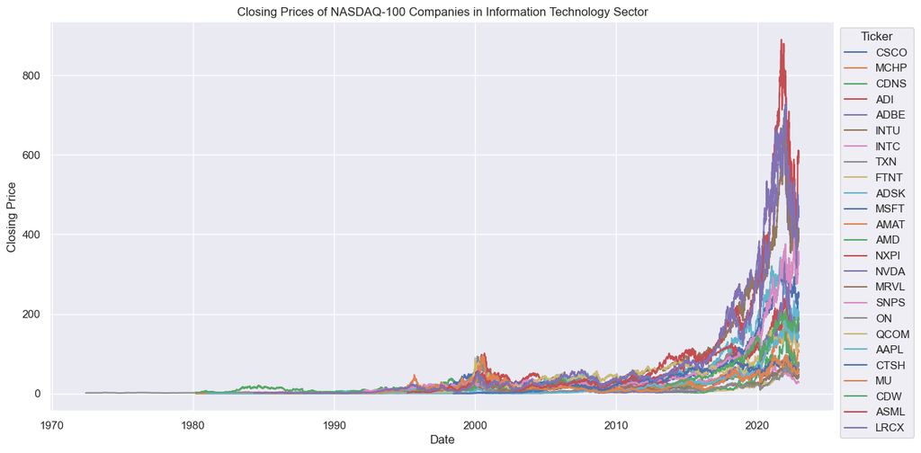

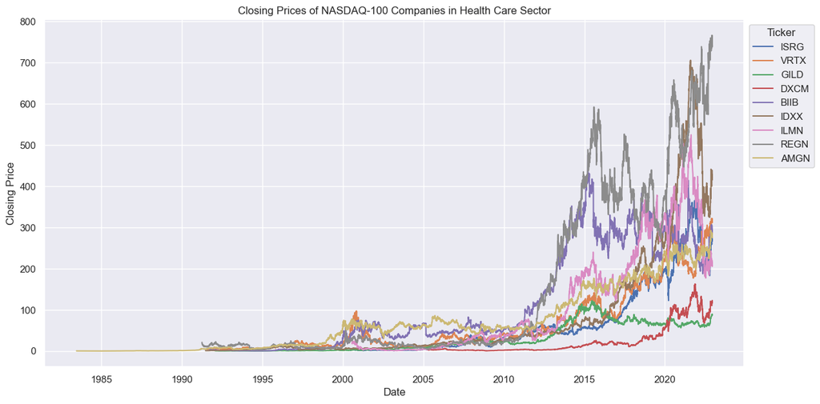

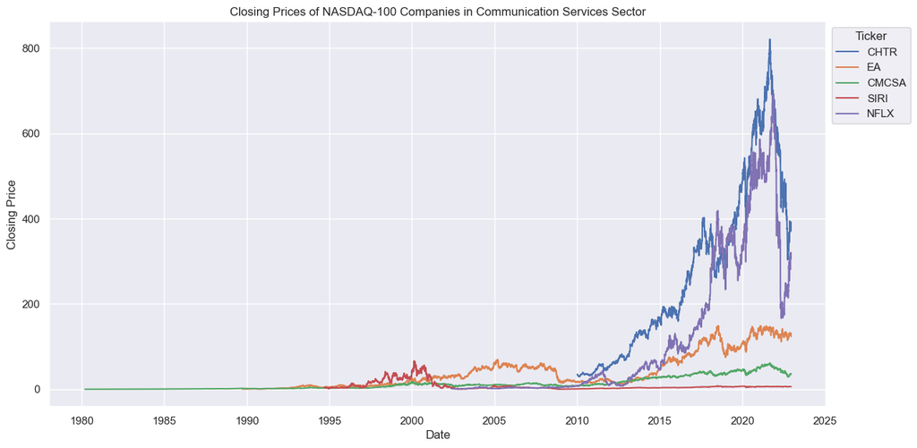

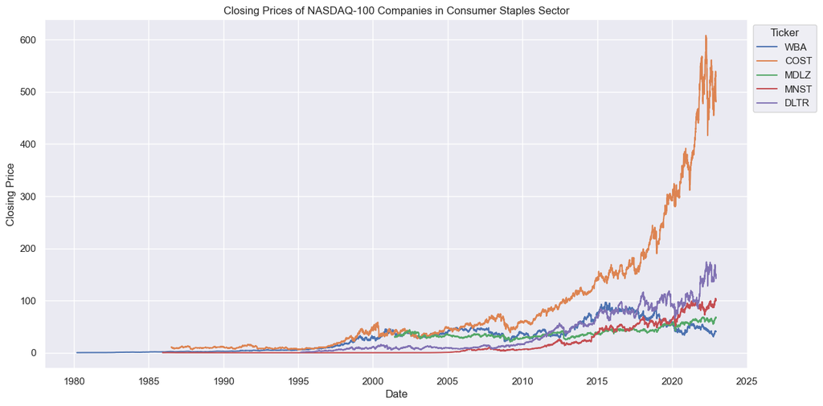

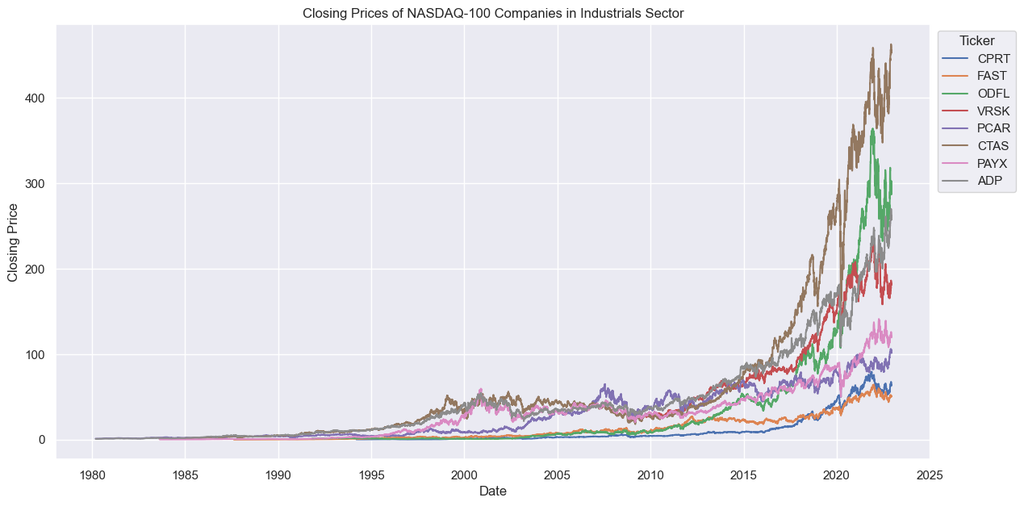

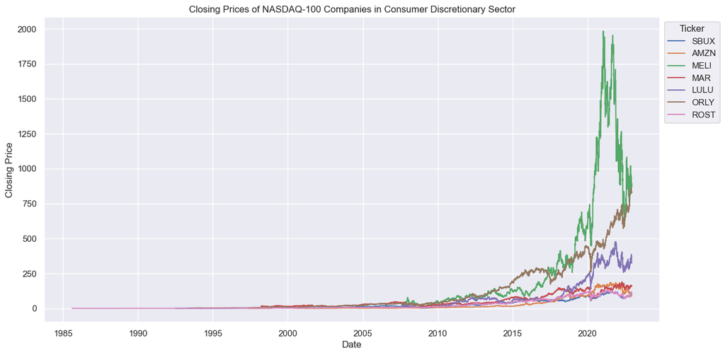

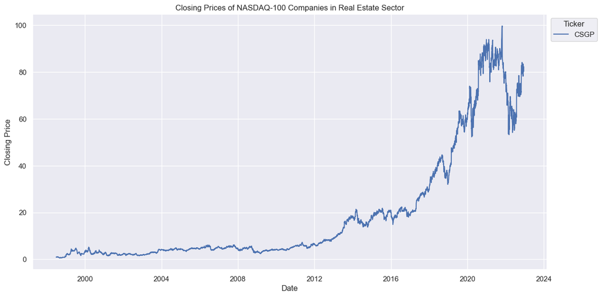

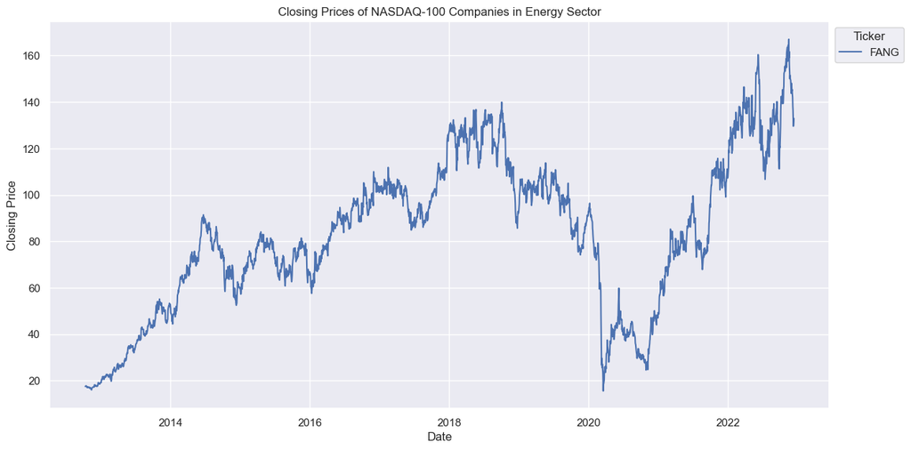

```python
import pandas as pd
import matplotlib.pyplot as plt
import seaborn as sns
import requests
from bs4 import BeautifulSoup
import os

# Step 1: Scrape current NASDAQ-100 components
url = 'https://en.wikipedia.org/wiki/Nasdaq-100#Components'
response = requests.get(url)
soup = BeautifulSoup(response.text, 'html.parser')
table = soup.find('table', {'class': 'wikitable sortable'})
current_nasdaq = pd.read_html(str(table))[0]

# Assuming the ticker is in a column named similar to 'Ticker'
current_nasdaq['Ticker'] = current_nasdaq['Ticker'].str.replace(r'\.', '', regex=True)  # Remove dots if present in tickers
current_tickers = current_nasdaq['Ticker'].tolist()

# Step 2: Load historical data and filter based on current tickers
directory_path = '/Users/edriskakar/Downloads/stock_market_data/nasdaq/csv'
all_files = os.listdir(directory_path)
csv_files = [f for f in all_files if f.endswith('.csv')]

# Define the expected columns in the CSV files
columns = ['Date', 'Low', 'Open', 'Volume', 'High', 'Close', 'Adjusted Close']

# Create an empty DataFrame to store the filtered data
filtered_data = pd.DataFrame()

# Loop through each CSV file
for file_name in csv_files:
    stock_symbol = file_name.replace('.csv', '')
    if stock_symbol in current_tickers:
        file_path = os.path.join(directory_path, file_name)
        try:
            # Read the CSV with predefined column names, skipping malformed lines
            stock_data = pd.read_csv(file_path, names=columns, skiprows=1, on_bad_lines='skip')
            stock_data['Ticker'] = stock_symbol
            filtered_data = pd.concat([filtered_data, stock_data], ignore_index=True)
        except Exception as e:
            print(f"Error processing {file_name}: {e}")

# Merge with GICS Sector data
merged_data = pd.merge(filtered_data, current_nasdaq[['Ticker', 'GICS Sector']], on='Ticker', how='left')

# Convert 'Date' column to datetime format
merged_data['Date'] = pd.to_datetime(merged_data['Date'], errors='coerce')

# Drop rows with any missing values
merged_data.dropna(inplace=True)

# Print the number of rows in the compiled DataFrame
print("Number of rows in the DataFrame:", len(merged_data))

# Show the first few rows of the compiled DataFrame
print(merged_data.head())

# Step 3: Plot the data
sns.set(style="darkgrid")

# Loop through each GICS Sector and create a plot for each sector
sectors = merged_data['GICS Sector'].unique()
for sector in sectors:
    plt.figure(figsize=(14, 7))
    sector_data = merged_data[merged_data['GICS Sector'] == sector]
    for ticker in sector_data['Ticker'].unique():
        ticker_data = sector_data[sector_data['Ticker'] == ticker]
        plt.plot(ticker_data['Date'], ticker_data['Close'], label=ticker)

    plt.title(f'Closing Prices of NASDAQ-100 Companies in {sector} Sector')
    plt.xlabel('Date')
    plt.ylabel('Closing Price')
    plt.legend(title='Ticker', loc='upper left', bbox_to_anchor=(1, 1))
    plt.show()
```

# Overview of the Code and Graph Analysis

The provided script serves the purpose of analyzing and visualizing the closing prices of NASDAQ-100 companies across different sectors. It starts by scraping NASDAQ-100 component data from Wikipedia to obtain current ticker symbols. This is followed by loading historical financial data from stored CSV files, specifically selecting those tickers present in the scraped NASDAQ-100 list. The script ensures data integrity by merging stock data with sector information and cleaning to remove any incomplete records. For visual analysis, the script utilizes Seaborn and Matplotlib to create a violin plot, effectively illustrating the distribution of closing prices by sector.

The resultant graph titled "Distribution of Closing Prices by GICS Sector for NASDAQ-100 Companies" employs violin plots to provide a comprehensive view of how stock closing prices are distributed within each sector. These plots not only show the density of data points, indicating common price ranges, but also highlight median prices and display variability and extremes within each sector. This visual representation allows for an intuitive comparison of sector performance, highlighting sectors with significant price variability and typical price behaviors. Such insights are invaluable for stakeholders looking to understand market trends, assess sector volatility, and make informed investment decisions based on detailed sectorial performance.

```
Number of rows in the DataFrame: 464697
        Date       Low  Open       Volume      High     Close  Adjusted Close Ticker  \
0 1990-02-16  0.073785   0.0  940636800.0  0.079861  0.077257        0.054863   CSCO
1 1990-02-20  0.074653   0.0  151862400.0  0.079861  0.079861        0.056712   CSCO
2 1990-02-21  0.075521   0.0   70531200.0  0.078993  0.078125        0.055479   CSCO
3 1990-02-22  0.078993   0.0   45216000.0  0.081597  0.078993        0.056095   CSCO
4 1990-02-23  0.078125   0.0   44697600.0  0.079861  0.078559        0.055787   CSCO

              GICS Sector
0  Information Technology
1  Information Technology
2  Information Technology
3  Information Technology
4  Information Technology
```

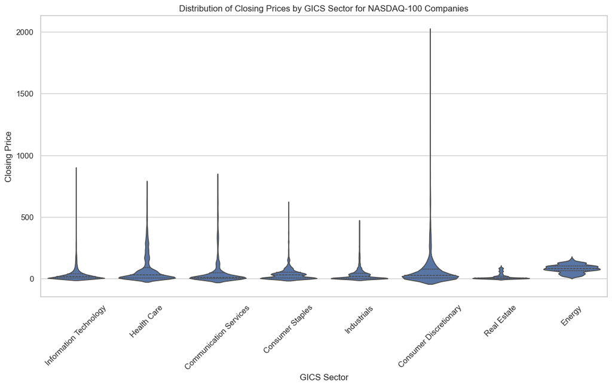

```python
import pandas as pd
import requests
from bs4 import BeautifulSoup
import os
import matplotlib.pyplot as plt
import seaborn as sns

# Step 1: Scrape current NASDAQ-100 components
url = 'https://en.wikipedia.org/wiki/Nasdaq-100#Components'
response = requests.get(url)
soup = BeautifulSoup(response.text, 'html.parser')
table = soup.find('table', {'class': 'wikitable sortable'})
current_nasdaq = pd.read_html(str(table))[0]

# Assuming the ticker is in a column named similar to 'Ticker'
current_nasdaq['Ticker'] = current_nasdaq['Ticker'].str.replace(r'\.', '', regex=True)  # Remove dots if present in tickers
current_tickers = current_nasdaq['Ticker'].tolist()

# Step 2: Load historical data and filter based on current tickers
directory_path = '/Users/edriskakar/Downloads/stock_market_data/nasdaq/csv'
all_files = os.listdir(directory_path)
csv_files = [f for f in all_files if f.endswith('.csv')]

# Define the expected columns in the CSV files
columns = ['Date', 'Low', 'Open', 'Volume', 'High', 'Close', 'Adjusted Close']

# Create an empty DataFrame to store the filtered data
filtered_data = pd.DataFrame()

# Loop through each CSV file
for file_name in csv_files:
    stock_symbol = file_name.replace('.csv', '')
    if stock_symbol in current_tickers:
        file_path = os.path.join(directory_path, file_name)
        try:
            # Read the CSV with predefined column names, skipping malformed lines
            stock_data = pd.read_csv(file_path, names=columns, skiprows=1, on_bad_lines='skip')
            stock_data['Ticker'] = stock_symbol
            filtered_data = pd.concat([filtered_data, stock_data], ignore_index=True)
        except Exception as e:
            print(f"Error processing {file_name}: {e}")

# Merge with GICS Sector data
merged_data = pd.merge(filtered_data, current_nasdaq[['Ticker', 'GICS Sector']], on='Ticker', how='left')

# Convert 'Date' column to datetime format
merged_data['Date'] = pd.to_datetime(merged_data['Date'], errors='coerce')

# Drop rows with any missing values
merged_data.dropna(inplace=True)

# Print the number of rows in the compiled DataFrame
print("Number of rows in the DataFrame:", len(merged_data))

# Show the first few rows of the compiled DataFrame
print(merged_data.head())

# Step 3: Create the Violin Plot
plt.figure(figsize=(14, 7))
sns.set(style="whitegrid")

# Create a violin plot for each GICS sector
sns.violinplot(x='GICS Sector', y='Close', data=merged_data, scale='width', inner='quartile')

plt.title('Distribution of Closing Prices by GICS Sector for NASDAQ-100 Companies')
plt.xlabel('GICS Sector')
plt.ylabel('Closing Price')
plt.xticks(rotation=45)
plt.show()
```

```
Number of rows in the DataFrame: 464449
        Date       Low  Open       Volume      High     Close  Adjusted Close Ticker  \
1 1990-02-20  0.074653   0.0  151862400.0  0.079861  0.079861        0.056712   CSCO
2 1990-02-21  0.075521   0.0   70531200.0  0.078993  0.078125        0.055479   CSCO
3 1990-02-22  0.078993   0.0   45216000.0  0.081597  0.078993        0.056095   CSCO
4 1990-02-23  0.078125   0.0   44697600.0  0.079861  0.078559        0.055787   CSCO
5 1990-02-26  0.076389   0.0   26928000.0  0.079861  0.076389        0.054246   CSCO

              GICS Sector    Growth  Change in Volume
1  Information Technology  3.370569        -83.855363
2  Information Technology -2.173777        -53.555851
3  Information Technology  1.111040        -35.892201
4  Information Technology -0.549421         -1.146497
5  Information Technology -2.762251        -39.755155
```

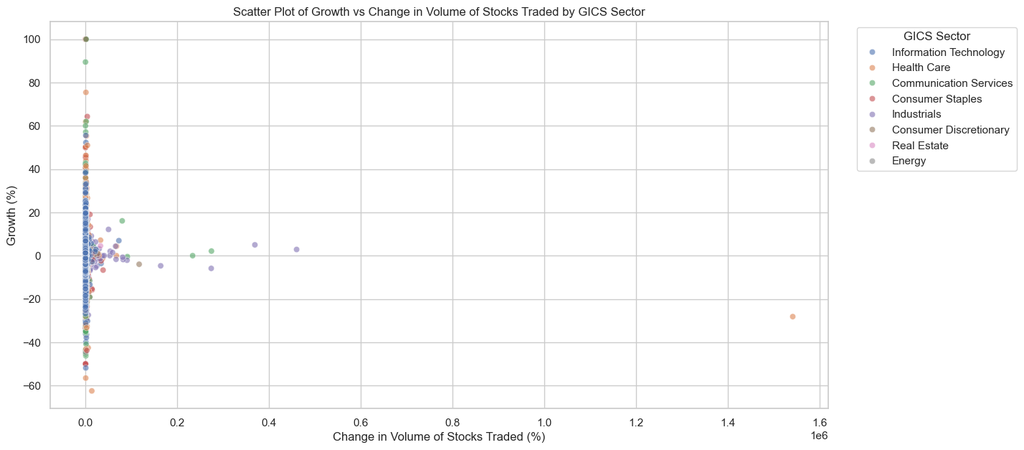

```python
import pandas as pd
import matplotlib.pyplot as plt
import seaborn as sns
import requests
from bs4 import BeautifulSoup
import os

# Step 1: Scrape current NASDAQ-100 components
url = 'https://en.wikipedia.org/wiki/Nasdaq-100#Components'
response = requests.get(url)
soup = BeautifulSoup(response.text, 'html.parser')
table = soup.find('table', {'class': 'wikitable sortable'})
current_nasdaq = pd.read_html(str(table))[0]

# Assuming the ticker is in a column named similar to 'Ticker'
current_nasdaq['Ticker'] = current_nasdaq['Ticker'].str.replace(r'\.', '', regex=True)  # Remove dots if present in tickers
current_tickers = current_nasdaq['Ticker'].tolist()

# Step 2: Load historical data and filter based on current tickers
directory_path = '/Users/edriskakar/Downloads/stock_market_data/nasdaq/csv'
all_files = os.listdir(directory_path)
csv_files = [f for f in all_files if f.endswith('.csv')]

# Define the expected columns in the CSV files
columns = ['Date', 'Low', 'Open', 'Volume', 'High', 'Close', 'Adjusted Close']

# Create an empty DataFrame to store the filtered data
filtered_data = pd.DataFrame()

# Loop through each CSV file
for file_name in csv_files:
    stock_symbol = file_name.replace('.csv', '')
    if stock_symbol in current_tickers:
        file_path = os.path.join(directory_path, file_name)
        try:
            # Read the CSV with predefined column names, skipping malformed lines
            stock_data = pd.read_csv(file_path, names=columns, skiprows=1, on_bad_lines='skip')
            stock_data['Ticker'] = stock_symbol
            filtered_data = pd.concat([filtered_data, stock_data], ignore_index=True)
        except Exception as e:
            print(f"Error processing {file_name}: {e}")

# Merge with GICS Sector data
merged_data = pd.merge(filtered_data, current_nasdaq[['Ticker', 'GICS Sector']], on='Ticker', how='left')

# Convert 'Date' column to datetime format
merged_data['Date'] = pd.to_datetime(merged_data['Date'], errors='coerce')

# Drop rows with any missing values
merged_data.dropna(inplace=True)

# Calculate growth as the percentage change in closing price
merged_data['Growth'] = merged_data.groupby('Ticker')['Close'].pct_change() * 100

# Calculate change in volume as the percentage change in volume
merged_data['Change in Volume'] = merged_data.groupby('Ticker')['Volume'].pct_change() * 100

# Drop rows where Growth or Change in Volume is NaN (first row for each ticker)
merged_data.dropna(subset=['Growth', 'Change in Volume'], inplace=True)

# Print the number of rows in the compiled DataFrame
print("Number of rows in the DataFrame:", len(merged_data))

# Show the first few rows of the compiled DataFrame
print(merged_data.head())

# Step 3: Create the Scatter Plot
plt.figure(figsize=(14, 7))
sns.set(style="whitegrid")

# Create a scatter plot
sns.scatterplot(x='Change in Volume', y='Growth', hue='GICS Sector', data=merged_data, alpha=0.6)

plt.title('Scatter Plot of Growth vs Change in Volume of Stocks Traded by GICS Sector')
plt.xlabel('Change in Volume of Stocks Traded (%)')
plt.ylabel('Growth (%)')
plt.legend(title='GICS Sector', loc='upper right', bbox_to_anchor=(1.25, 1))
plt.show()
```

```
        Date     Close
0 1972-06-01  1.701823
1 1972-06-02  1.733073
2 1972-06-05  1.735677
3 1972-06-06  1.662760
4 1972-06-07  1.656250
```

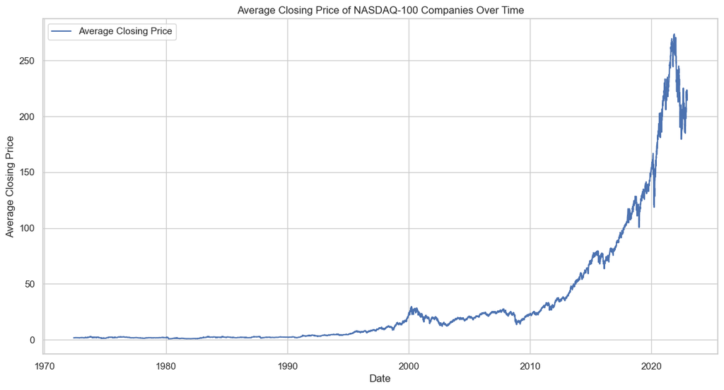

```python
import pandas as pd
import matplotlib.pyplot as plt
import seaborn as sns
import requests
from bs4 import BeautifulSoup
import os

# Step 1: Scrape current NASDAQ-100 components
url = 'https://en.wikipedia.org/wiki/Nasdaq-100#Components'
response = requests.get(url)
soup = BeautifulSoup(response.text, 'html.parser')
table = soup.find('table', {'class': 'wikitable sortable'})
current_nasdaq = pd.read_html(str(table))[0]

# Assuming the ticker is in a column named similar to 'Ticker'
current_nasdaq['Ticker'] = current_nasdaq['Ticker'].str.replace(r'\.', '', regex=True)  # Remove dots if present in tickers
current_tickers = current_nasdaq['Ticker'].tolist()

# Step 2: Load historical data and filter based on current tickers
directory_path = '/Users/edriskakar/Downloads/stock_market_data/nasdaq/csv'
all_files = os.listdir(directory_path)
csv_files = [f for f in all_files if f.endswith('.csv')]

# Define the expected columns in the CSV files
columns = ['Date', 'Low', 'Open', 'Volume', 'High', 'Close', 'Adjusted Close']

# Create an empty DataFrame to store the filtered data
filtered_data = pd.DataFrame()

# Loop through each CSV file
for file_name in csv_files:
    stock_symbol = file_name.replace('.csv', '')
    if stock_symbol in current_tickers:
        file_path = os.path.join(directory_path, file_name)
        try:
            # Read the CSV with predefined column names, skipping malformed lines
            stock_data = pd.read_csv(file_path, names=columns, skiprows=1, on_bad_lines='skip')
            stock_data['Ticker'] = stock_symbol
            filtered_data = pd.concat([filtered_data, stock_data], ignore_index=True)
        except Exception as e:
            print(f"Error processing {file_name}: {e}")

# Convert 'Date' column to datetime format
filtered_data['Date'] = pd.to_datetime(filtered_data['Date'], errors='coerce')

# Drop rows with any missing values
filtered_data.dropna(inplace=True)

# Calculate the average closing price for each date
average_closing_prices = filtered_data.groupby('Date')['Close'].mean().reset_index()

# Print the first few rows of the average closing prices
print(average_closing_prices.head())

# Step 3: Plot the average closing prices over time
plt.figure(figsize=(14, 7))
sns.set(style="whitegrid")

# Create a line plot for average closing prices
plt.plot(average_closing_prices['Date'], average_closing_prices['Close'], label='Average Closing Price', color='b')

plt.title('Average Closing Price of NASDAQ-100 Companies Over Time')
plt.xlabel('Date')
plt.ylabel('Average Closing Price')
plt.legend()
plt.show()
```

The Python script executes a comprehensive process that begins with scraping the NASDAQ-100 components from Wikipedia to capture the current listed companies. This data, particularly the ticker symbols, serves as a filter for loading specific historical stock data. The script then accesses a specified directory containing stock data in CSV files, loading data only for those tickers present in the NASDAQ-100 index. Each CSV file is read, ensuring it includes the necessary columns like Date, Open, High, Low, Close, Volume, and Adjusted Close. Malformed lines are skipped to maintain data integrity. This data is compiled into a single DataFrame, which is then cleaned to ensure dates are in a consistent datetime format and any rows with missing values are removed. Subsequently, the script calculates the average closing price per date across all NASDAQ-100 stocks, which involves grouping the data by date and averaging the 'Close' values. This summary statistic provides a snapshot of the collective performance of these top-tier stocks over time, smoothing out individual fluctuations and focusing on broader market trends. Finally, the script visualizes this data by plotting the average closing prices against dates on a line graph. This graph provides a clear visual representation of the trends in NASDAQ-100 companies' stock prices over time, showing how they have changed and highlighting any significant increases or declines. This can be particularly useful for historical analysis of market behavior, identifying periods of growth, stability, or decline within the index. The cell above is just solely for making graph while below it calculates these three values as well.

```
Average Compounded Growth for NASDAQ-100: 29899.74%
Sum magnitude of growth: 878400.13
Average magnitude of growth: 1.89%
```

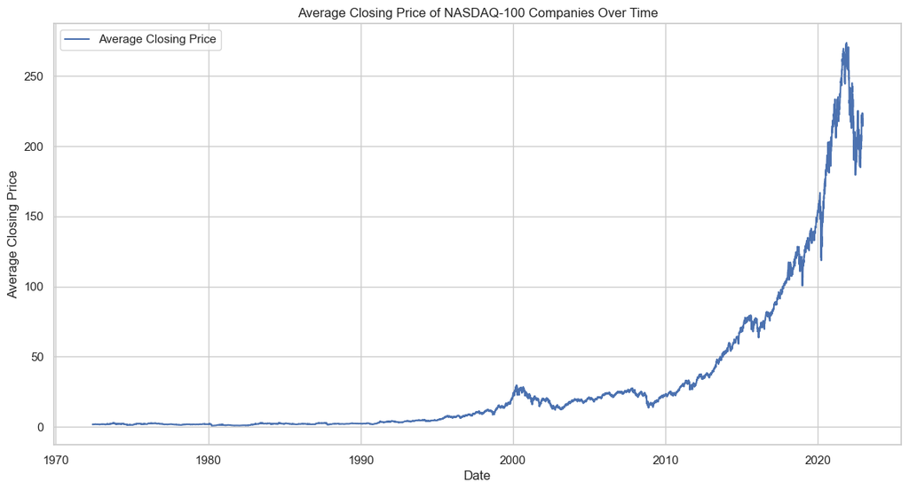

```python
import pandas as pd
import requests
from bs4 import BeautifulSoup
import os

# Step 1: Scrape current NASDAQ-100 components
url = 'https://en.wikipedia.org/wiki/Nasdaq-100#Components'
response = requests.get(url)
soup = BeautifulSoup(response.text, 'html.parser')
table = soup.find('table', {'class': 'wikitable sortable'})
current_nasdaq = pd.read_html(str(table))[0]

# Assuming the ticker is in a column named similar to 'Ticker'
current_nasdaq['Ticker'] = current_nasdaq['Ticker'].str.replace(r'\.', '', regex=True)  # Remove dots if present in tickers
current_tickers = current_nasdaq['Ticker'].tolist()

# Step 2: Load historical data and filter based on current tickers
directory_path = '/Users/edriskakar/Downloads/stock_market_data/nasdaq/csv'
all_files = os.listdir(directory_path)
csv_files = [f for f in all_files if f.endswith('.csv')]

# Define the expected columns in the CSV files
columns = ['Date', 'Low', 'Open', 'Volume', 'High', 'Close', 'Adjusted Close']

# Create an empty DataFrame to store the filtered data
filtered_data = pd.DataFrame()

# Loop through each CSV file
for file_name in csv_files:
    stock_symbol = file_name.replace('.csv', '')
    if stock_symbol in current_tickers:
        file_path = os.path.join(directory_path, file_name)
        try:
            # Read the CSV with predefined column names, skipping malformed lines
            stock_data = pd.read_csv(file_path, names=columns, skiprows=1, on_bad_lines='skip')
            stock_data['Ticker'] = stock_symbol
            filtered_data = pd.concat([filtered_data, stock_data], ignore_index=True)
        except Exception as e:
            print(f"Error processing {file_name}: {e}")

# Convert 'Date' column to datetime format
filtered_data['Date'] = pd.to_datetime(filtered_data['Date'], errors='coerce')

# Drop rows with any missing values
filtered_data.dropna(inplace=True)

# Calculate daily growth (percentage change in closing price)
filtered_data['Growth'] = filtered_data.groupby('Ticker')['Close'].pct_change() * 100

# Drop rows where Growth is NaN (first row for each ticker)
filtered_data.dropna(subset=['Growth'], inplace=True)

# Calculate compounded growth for the entire period
compounded_growth = (filtered_data.groupby('Ticker')['Close'].apply(lambda x: (x.iloc[-1] / x.iloc[0]) - 1) * 100).mean()
print(f"Average Compounded Growth for NASDAQ-100: {compounded_growth:.2f}%")

# Calculate the average magnitude of growth each day
sum_magnitude = filtered_data['Growth'].abs().sum()
average_magnitude_of_growth = sum_magnitude / len(filtered_data)
print(f"Sum magnitude of growth: {sum_magnitude:.2f}")
print(f"Average magnitude of growth: {average_magnitude_of_growth:.2f}%")

# Optionally, plot the average closing price over time
average_closing_prices = filtered_data.groupby('Date')['Close'].mean().reset_index()

plt.figure(figsize=(14, 7))
plt.plot(average_closing_prices['Date'], average_closing_prices['Close'], label='Average Closing Price', color='b')
plt.title('Average Closing Price of NASDAQ-100 Companies Over Time')
plt.xlabel('Date')
plt.ylabel('Average Closing Price')
plt.legend()
plt.show()
```

The code begins by scraping the list of current NASDAQ-100 components from Wikipedia, ensuring that the latest company data is used for the analysis. This is crucial as the stock market is highly dynamic and company listings on indices like the NASDAQ-100 can frequently change. The tickers are extracted and any dots within them are removed to maintain consistency.

Following data acquisition, the code loads historical stock data from a predefined directory. This data includes several features such as open, high, low, close, and volume of stocks traded, crucial for analyzing stock performance. The stocks included in the analysis are filtered to ensure that only those that are part of the NASDAQ-100 are considered.

To prepare this data for modeling, it is first cleaned and pre-processed. Dates are converted into a proper datetime format, and any rows with missing dates are discarded to maintain data integrity. The feature engineering step involves calculating the 'Previous Close' for each stock, which represents the last closing price and is used to predict the next day's closing price.

The data is then split into training and testing sets to evaluate the model's performance. A portion of the training set is further split into a validation set to fine-tune model parameters without overfitting. The model is trained using linear regression, a simple yet powerful technique for numerical prediction tasks. After training, predictions are made on both the test and validation sets.

The performance of the model is assessed using several statistical metrics:

- **Mean Squared Error (MSE)** and **Root Mean Squared Error (RMSE)**: Indicate the average squared difference and the square root of this difference between the observed actual outcomes and the outcomes predicted by the model.
- **Mean Absolute Error (MAE)**: Represents the average of the absolute differences between the predicted values and actual values, giving an idea of how wrong the predictions were.
- **R-squared (R²)** and **Adjusted R-squared**: Measure the proportion of variance in the dependent variable that is predictable from the independent variables and adjusts for the number of predictors in the model, which is useful for comparison with other models.

These metrics show that the model is highly accurate, with MSE, RMSE, and MAE values indicating small errors, and R² and Adjusted R² values close to 1, suggesting excellent model fit. This implies that the model can reliably predict the closing prices of NASDAQ-100 stocks, making it a valuable tool for investors and analysts looking to understand market trends or make investment decisions based on historical data.

```python
import pandas as pd
import requests
from bs4 import BeautifulSoup
import os
from sklearn.model_selection import train_test_split
from sklearn.linear_model import LinearRegression
from sklearn.metrics import mean_squared_error, r2_score
from sklearn.metrics import mean_absolute_error


# Scrape NASDAQ-100 components
url = 'https://en.wikipedia.org/wiki/Nasdaq-100#Components'
response = requests.get(url)
soup = BeautifulSoup(response.text, 'html.parser')
table = soup.find('table', {'class': 'wikitable sortable'})
current_nasdaq = pd.read_html(str(table))[0]

current_nasdaq['Ticker'] = current_nasdaq['Ticker'].str.replace(r'\.', '', regex=True)
current_tickers = current_nasdaq['Ticker'].tolist()

# Load and filter historical data
directory_path = '/Users/edriskakar/Downloads/stock_market_data/nasdaq/csv'
all_files = os.listdir(directory_path)
csv_files = [f for f in all_files if f.endswith('.csv')]
columns = ['Date', 'Low', 'Open', 'Volume', 'High', 'Close', 'Adjusted Close']
filtered_data = pd.DataFrame()

for file_name in csv_files:
    stock_symbol = file_name.replace('.csv', '')
    if stock_symbol in current_tickers:
        file_path = os.path.join(directory_path, file_name)
        stock_data = pd.read_csv(file_path, names=columns, skiprows=1, on_bad_lines='skip')
        stock_data['Ticker'] = stock_symbol
        filtered_data = pd.concat([filtered_data, stock_data], ignore_index=True)

# Attempt to parse dates, specifying expected format and coercing errors
try:
    filtered_data['Date'] = pd.to_datetime(filtered_data['Date'], format='%d-%m-%Y', errors='coerce')
except ValueError:
    # If there are multiple formats, try without specifying the format
    filtered_data['Date'] = pd.to_datetime(filtered_data['Date'], errors='coerce')

filtered_data.sort_values('Date', inplace=True)
filtered_data.dropna(subset=['Date'], inplace=True)  # Drop rows where dates could not be parsed

# Feature Engineering
filtered_data['Prev_Close'] = filtered_data.groupby('Ticker')['Close'].shift(1)
filtered_data.dropna(inplace=True)  # Removing NaN values after shifting

# Prepare data for ML
X = filtered_data[['Volume', 'Prev_Close']]
y = filtered_data['Close']
X_train, X_test, y_train, y_test = train_test_split(X, y, test_size=0.2, random_state=42)

# Define and train the model
model = LinearRegression()
model.fit(X_train, y_train)
y_pred = model.predict(X_test)

# Evaluate the model
mse = mean_squared_error(y_test, y_pred)
r2 = r2_score(y_test, y_pred)
print(f"Mean Squared Error: {mse}, R^2 Score: {r2}")
X = filtered_data[['Volume', 'Prev_Close']]  # Independent variables
y = filtered_data['Close']  # Dependent variable (target)

# Splitting the data into training and testing sets
X_train, X_test, y_train, y_test = train_test_split(X, y, test_size=0.2, random_state=42)

# Further split the training data into training and validation sets
X_train_part, X_val, y_train_part, y_val = train_test_split(X_train, y_train, test_size=0.25, random_state=42)  # 0.25 x 0.8 = 0.2

# Define and train the Linear Regression model
model = LinearRegression()
model.fit(X_train_part, y_train_part)

# Predictions for validation and test sets
y_val_pred = model.predict(X_val)
y_test_pred = model.predict(X_test)

# Evaluate the model
mse_val = mean_squared_error(y_val, y_val_pred)
r2_val = r2_score(y_val, y_val_pred)
mse_test = mean_squared_error(y_test, y_test_pred)
r2_test = r2_score(y_test, y_test_pred)

print(f"Validation MSE: {mse_val}, Validation R^2: {r2_val}")
print(f"Test MSE: {mse_test}, Test R^2: {r2_test}")

rmse_test = mean_squared_error(y_test, y_test_pred, squared=False)

# MAE Calculation
mae_test = mean_absolute_error(y_test, y_test_pred)

# Adjusted R-squared Calculation
def adjusted_r2(r_square, labels, features):
    adj_r_squared = 1 - ((1 - r_square) * (len(labels) - 1)) / (len(labels) - features.shape[1] - 1)
    return adj_r_squared

adj_r2_val = adjusted_r2(r2_val, y_val, X_val)
adj_r2_test = adjusted_r2(r2_test, y_test, X_test)

print(f"Test RMSE: {rmse_test}")
print(f"Test MAE: {mae_test}")
print(f"Validation Adjusted R²: {adj_r2_val}")
print(f"Test Adjusted R²: {adj_r2_test}")
```

```
Mean Squared Error: 7.725206133771539, R^2 Score: 0.9992453938891476
Validation MSE: 7.96802066563735, Validation R^2: 0.9991726744130284
Test MSE: 7.729541626453284, Test R^2: 0.9992449703937464
Test RMSE: 2.7802053209166555
Test MAE: 0.8142762414268677
Validation Adjusted R²: 0.9991726566065288
Test Adjusted R²: 0.9992449541434455
```

This tutorial was designed to enhance your understanding of applying machine learning techniques to predict stock market trends, particularly with NASDAQ-100 stock data. It is evident that as technology progresses, the potential for machine learning tools in finance will expand significantly. Machines have already shown promising results in making precise short-term investment predictions, often surpassing human capabilities.

Understanding these dynamics now prepares us not only to leverage these technologies but also to innovate responsibly as we navigate through the evolving landscape of financial technology.